# Lecture 08: Review of DOE - Part 2

Natalie Sawtelle

2025-09-22

## Before we start

We will work this assignment as a big group. We picked the example and the style to complete the assignment (live coding) based on student feedback.

## Data Description

Golf is one of the most popular recreational sports in the United States. The driver is one of the more important clubs as a golfer will generally use it on the first shot of a hole when wishing to hit the ball off a tee for very long distances. The act of hitting a golf ball requires precision, skill and strength but the club can influence a shot as well. A golf manufacturer is looking to improve their product line of golf drivers to increase shot distance. Four protoype drivers are considered:

- **Driver 1**: mass of 270g and a length of 117.5cm
- **Driver 2**: mass of 290g and a length of 116.2cm
- **Driver 3**: mass of 310g and a length of 115.0cm
- **Driver 4**: mass of 340g and a length of 113.4cm

The manufacturer recruited 6 golfers to test each of the four drivers. Each golfer used each driver once, in a randomly assigned order, and the manufacturer recorded several variables related to the shot. Of particular interest to the manufacturer is determining if certain drivers result in longer distance shots.

Perform a complete statistical analysis assessing the manufacturer’s questions.

## Design Type

What type of design is this?

**One way Block design**

- Experimental units = clubs
- Response = totdist (total driving distance)
- Factor = club (driver type)
  - Factor levels = 1, 2, 3, 4
  - Treatments = Driver 1, 2, 3, 4
- Block = golfer (6 golfers participating in the experiment)
  - each golfer has a different skill set, thus their ability to diver the ball is directly effected by their skill set
  - golfer is a known effect which we are **NOT** interested in, but we need to account for it in our model
- Control
  - Control group (not really here)
  - **Randomization = clubs assigned randomly**
  - **Replication = multiple observations per treatment (club type)**
  - Every golfer gets every club
  - Blinding (not realy here)

## Data Input

The following is provided to you.

```r
golf_data <- read_csv("golf_driver.csv",
                      show_col_types = FALSE)
glimpse(golf_data)
```

```
## Rows: 24
## Columns: 6
## $ club      <dbl> 1, 1, 1, 1, 1, 1, 2, 2, 2, 2, 2, 2, 3, 3, 3, 3, 3, 3, 4, 4, …
## $ golfer    <dbl> 1, 2, 3, 4, 5, 6, 1, 2, 3, 4, 5, 6, 1, 2, 3, 4, 5, 6, 1, 2, …
## $ backspin  <dbl> 2675, 3775, 2550, 2350, 3138, 3150, 2475, 3225, 2338, 2575, …
## $ totdist   <dbl> 256, 252, 293, 265, 258, 228, 259, 258, 297, 262, 262, 236, …
## $ ballspeed <dbl> 243, 252, 275, 258, 251, 223, 243, 249, 273, 275, 248, 225, …
## $ launchang <dbl> 9.6, 11.8, 9.9, 7.8, 12.3, 11.8, 9.7, 11.1, 9.1, 7.0, 10.8, …
```

```r
# all variables are listed as <dbl> -- meaning all variables are currently numeric
```

## Data Processing

Note that both the `club` and `golfer` variables are recorded as numbers. Both **must be** categorical, or `factor`, variables to perform the correct analysis.

Perform some data munging to convert both to `factor` variables.

```r
# update the dataset --> data <- data |> mutate()
# labels = c() <-- indicates a list of objects

golf_data <- golf_data |>
  mutate(club = factor(club,
                       labels = c("Driver 1", "Driver 2", "Driver 3", "Driver 4")),
         golfer = factor(golfer)) |>
  # simplify our data - only include variables needed
  # select() will subset a data frame by columns
  select(club, golfer, totdist)
```

## EDA

Build a profile plot for each golfer and provide an overall “average” profile across all golfers.

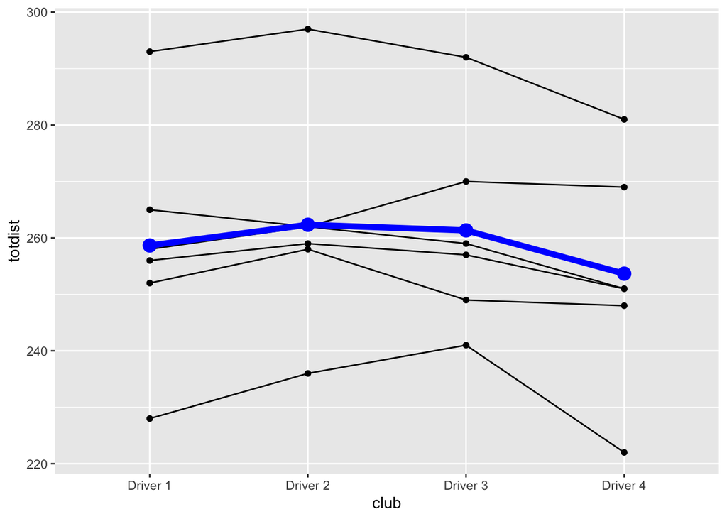

```r
# aes statement identifies variables used in the layers of the plot
# aes in the ggplot -- all aes components applied to all layers
# aes in a specific layer -- only applied to that line of code

# club = factor, totdist = response, golfer = block
ggplot(golf_data, aes(x=club, y=totdist, group=golfer))+
  # plotting the individual observations of the BLOCKS
  geom_point() +
  geom_line() +
  # summary across all golfers - override the group statement -- setting the group to 1 ("dummy input)
  stat_summary(fun=mean, geom="point", size=4, color="blue", group=1)+
  stat_summary(fun=mean, geom="line", size=2, color="blue", group=1)
```

**ANALYSIS**

## ANOVA Model

Fit the appropriate ANOVA model to this data

```r
golf_anova <- aov(totdist ~ golfer + club, data = golf_data)
```

## Residual Analysis

Assess the assumptions of this model

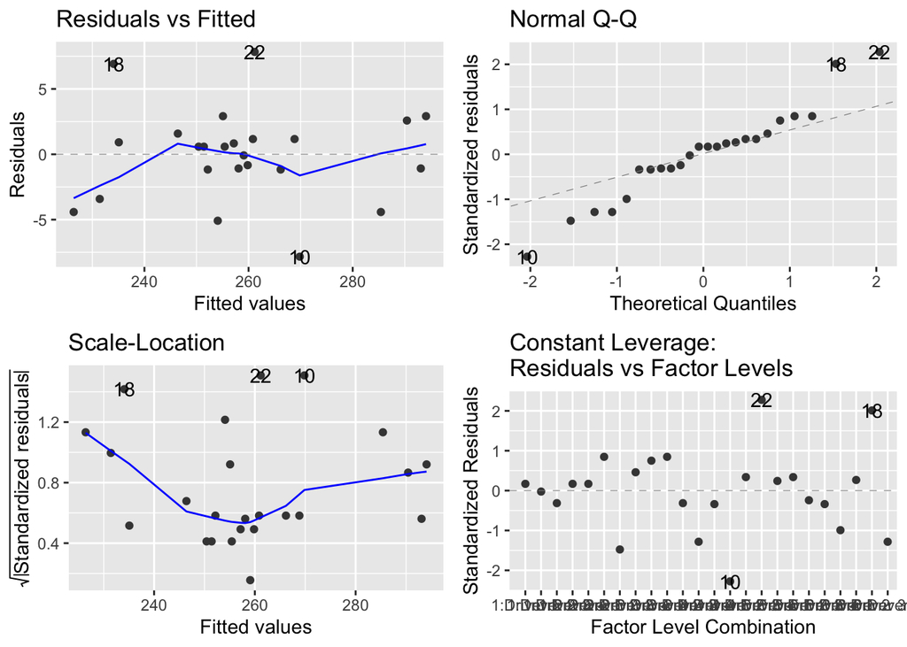

```r
autoplot(golf_anova)
```

## Assumptions

- Independence - design type – if randomization, then this can be assumed
- Constant variance - Residuals vs. Fitted – is there a pattern of fanning
  - were good if no fanning, problem with constant varience if there is
- Normality - Normal QQ – do the residual plots follow the 45-degree line

**The residuals are fairly evenly spread out, there is no clear pattern or treat of increasing or decreasing variation. The points are not perfectly following the Normal QQ plot trend line, but they are good enough.**

## ANOVA Hypothesis Test

Perform the appropriate hypothesis test for this design.

```r
summary(golf_anova)
```

```
##             Df Sum Sq Mean Sq F value  Pr(>F)
## golfer       5   7489  1497.8   79.02 3.1e-10 ***
## club         3    271    90.2    4.76  0.0159 *
## Residuals   15    284    19.0
## ---
## Signif. codes:  0 '***' 0.001 '**' 0.01 '*' 0.05 '.' 0.1 ' ' 1
```

- ignore the block effect!!!
- only look at the factor of interest

with an F-stat of 4.76 pm 3 and 15 degrees of freedom (p-value = 0.0159)